# STAT 486/586

### Logarithmic axis

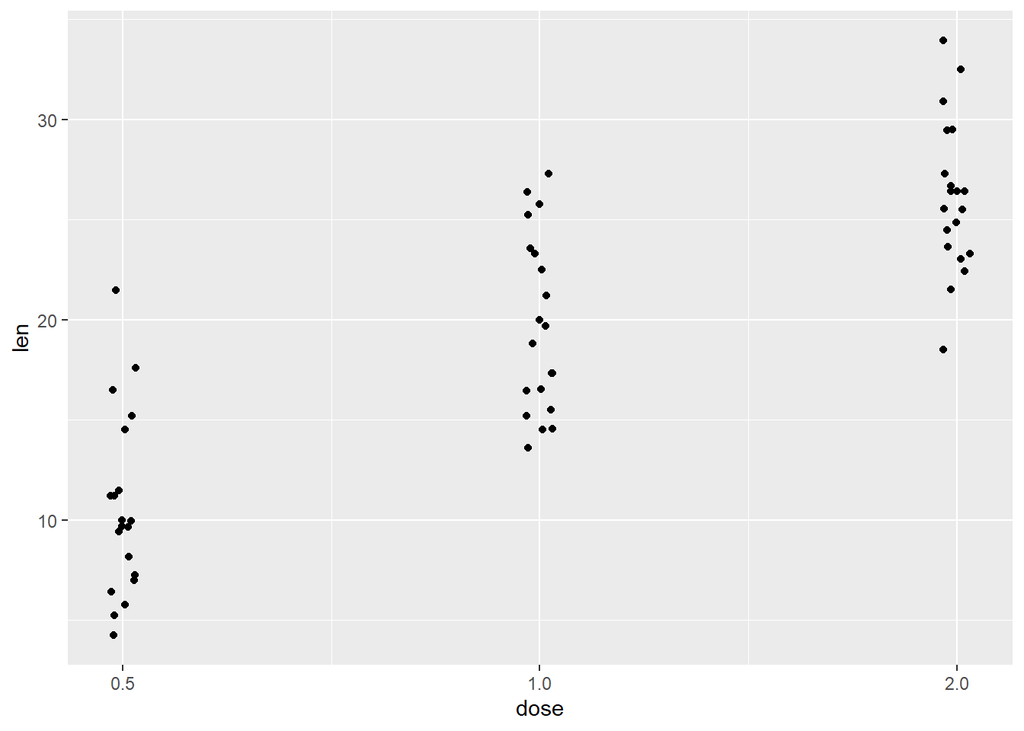

```r
ggplot(ToothGrowth, aes(x = dose, y = len)) +
  geom_jitter(width=0.01) +
  scale_x_log10()
```

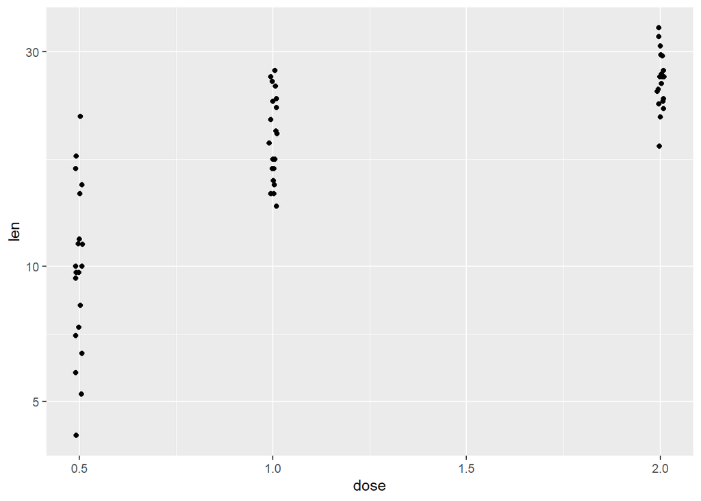

```r
ggplot(ToothGrowth, aes(x = dose, y = len)) +
  geom_jitter(width=0.01) +
  scale_y_log10()
```

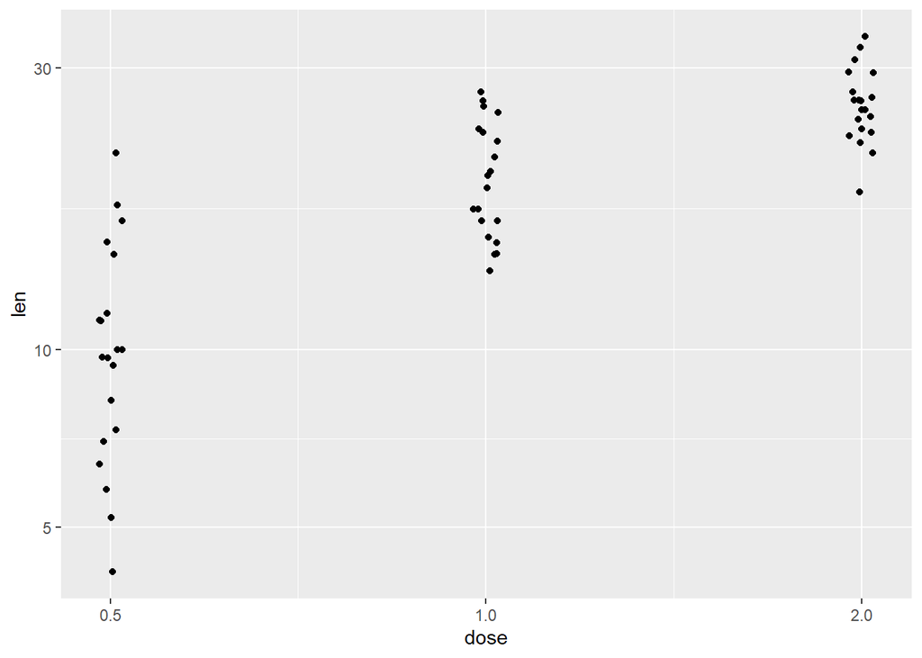

```r
ggplot(ToothGrowth, aes(x = dose, y = len)) +
  geom_jitter(width=0.01) +
  scale_x_log10() +
  scale_y_log10()
```

### Colors and shapes

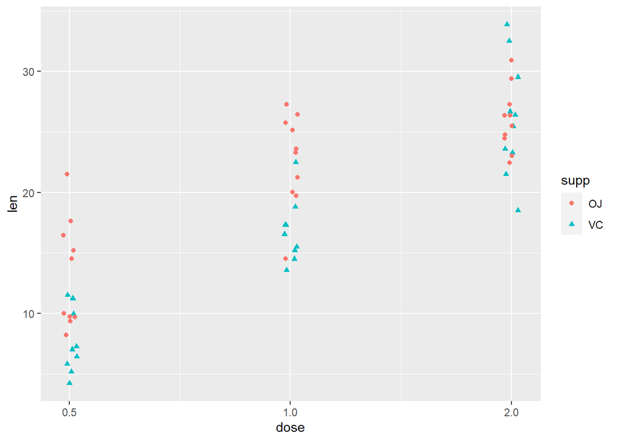

```r
ggplot(ToothGrowth, aes(x = dose, y = len, color = supp, shape = supp)) +
  geom_jitter(width=0.01) +
  scale_x_log10()
```

We can also specify colors and shapes.

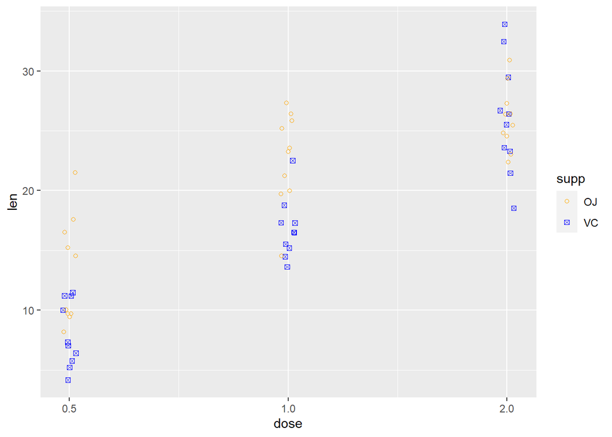

```r
ggplot(ToothGrowth, aes(x = dose, y = len, color = supp, shape = supp)) +
  geom_jitter(width=0.01) +
  scale_color_manual(
    values =
      c(
        OJ = "orange",
        VC = "blue"
      )) +
  scale_shape_manual(
    values =
      c(
        OJ = 21,
        VC = 7
      )
  ) +
  scale_x_log10()
```

To see what [shapes](http://www.sthda.com/english/wiki/r-plot-pch-symbols-the-different-point-shapes-available-in-r) and colors are available, use

```r
?points
colors()
```

You can also specify colors using `rgb()` or `col2rgb()`. Here is my [ISU color palette](https://www.jarad.me/consulting/2017/09/07/ggplot2-ISU-palette).

### Regression line

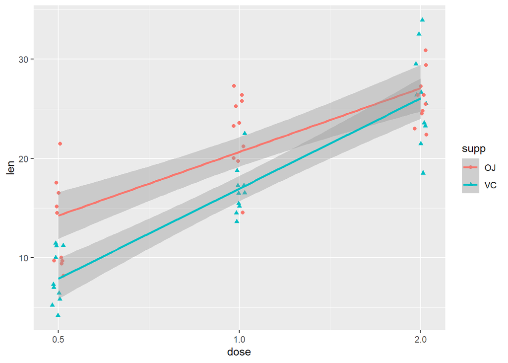

```r
ggplot(ToothGrowth, aes(x = dose, y = len, color = supp, shape = supp)) +
  geom_jitter(width=0.01) +
  scale_x_log10() +
  geom_smooth(method = "lm")
```

Are these lines parallel?

```r
m <- lm(len ~ dose*supp, data = ToothGrowth)
anova(m)
```

```
## Analysis of Variance Table
##
## Response: len
##           Df  Sum Sq Mean Sq  F value    Pr(>F)
## dose       1 2224.30 2224.30 133.4151 < 2.2e-16 ***
## supp       1  205.35  205.35  12.3170 0.0008936 ***
## dose:supp  1   88.92   88.92   5.3335 0.0246314 *
## Residuals 56  933.63   16.67
## ---
## Signif. codes:  0 '***' 0.001 '**' 0.01 '*' 0.05 '.' 0.1 ' ' 1
```

## Professional graphics

To construct professional looking graphics, we need to modify and customizing much of the look of these default graphics. We will use a combination of modifying the underlying data as well as modify the output graphic.

### Labels

Improve underlying data.

```r
d <- ToothGrowth %>%
  rename(
    Length = len,
    Delivery = supp,
    Dose = dose) %>%
  mutate(Delivery = fct_recode(Delivery,
                               "Orange Juice" = "OJ",
                               "Ascorbic Acid" = "VC"))
```

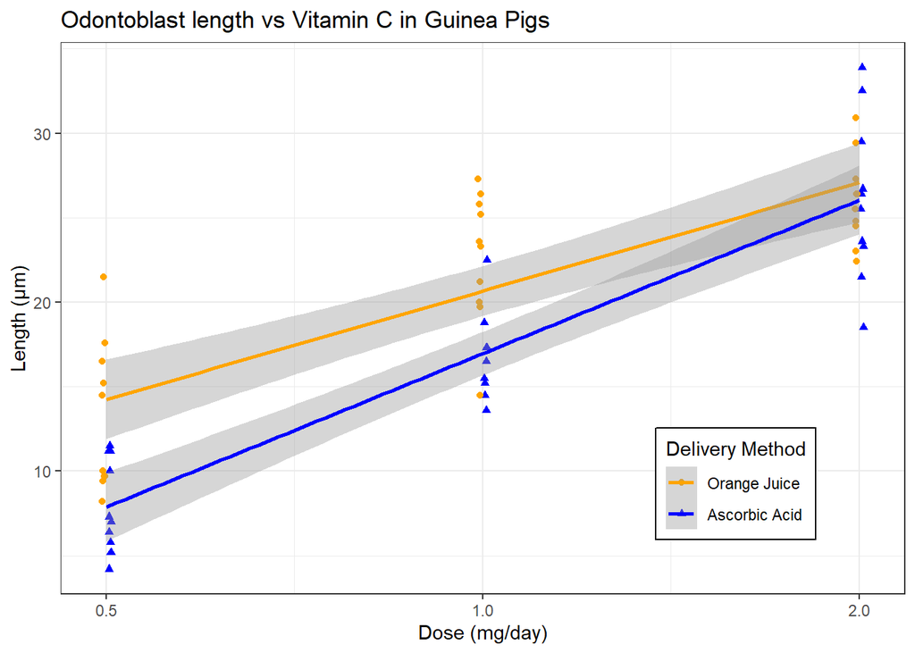

```r
ggplot(d,                       # Note the new data.frame
       aes(
         x = Dose,
         y = Length,
         color = Delivery,
         shape = Delivery)) +
  geom_point(position = position_jitterdodge(
    jitter.width = 0.005,
    dodge.width = 0.01           # moves Delivery method left and right of Dose
  )) +
  scale_x_log10() +
  scale_color_manual(
    values = c("Orange Juice" = "orange",
               "Ascorbic Acid" = "blue")
  ) +
  geom_smooth(method = "lm") +
  labs(
    x = "Dose (mg/day)",
    y = "Length (\u00b5m)", # unicode \u005b is the Greek letter mu
    title = "Odontoblast length vs Vitamin C in Guinea Pigs",
    color = "Delivery Method",
    shape = "Delivery Method") +
  theme_bw() +
  theme(legend.position = c(0.8, 0.2),
        legend.background = element_rect(fill = "white",
                                        color = "black"))
```

### Save the graphic

```r
# Save to an object
g <- ggplot(d,
       aes(
         x = Dose,
         y = Length,
         color = Delivery,
         shape = Delivery)) +
  geom_point(position = position_jitterdodge(
    jitter.width = 0.005,
    dodge.width = 0.01
  )) +
  scale_x_log10() +
  scale_color_manual(
    values = c("Orange Juice" = "orange",
               "Ascorbic Acid" = "blue")
  ) +
  geom_smooth(method = "lm") +
  labs(
    x = "Dose (mg/day)",
    y = "Length (\u00b5m)", # unicode \u005b is the Greek letter mu
    title = "Odontoblast length vs Vitamin C in Guinea Pigs",
    color = "Delivery Method",
    shape = "Delivery Method") +
  theme_bw() +
  theme(legend.position = c(0.8, 0.2),
        legend.background = element_rect(fill = "white",
                                        color = "black"))

# Write to a file
fn <- "toothgrowth.png"
ggsave(fn, plot = g, width = 6, height = 4)
# Clean up
unlink(fn) # remove the file
```

## Diamonds data set

```r
?diamonds
```

What kind of informative plot can you construct?

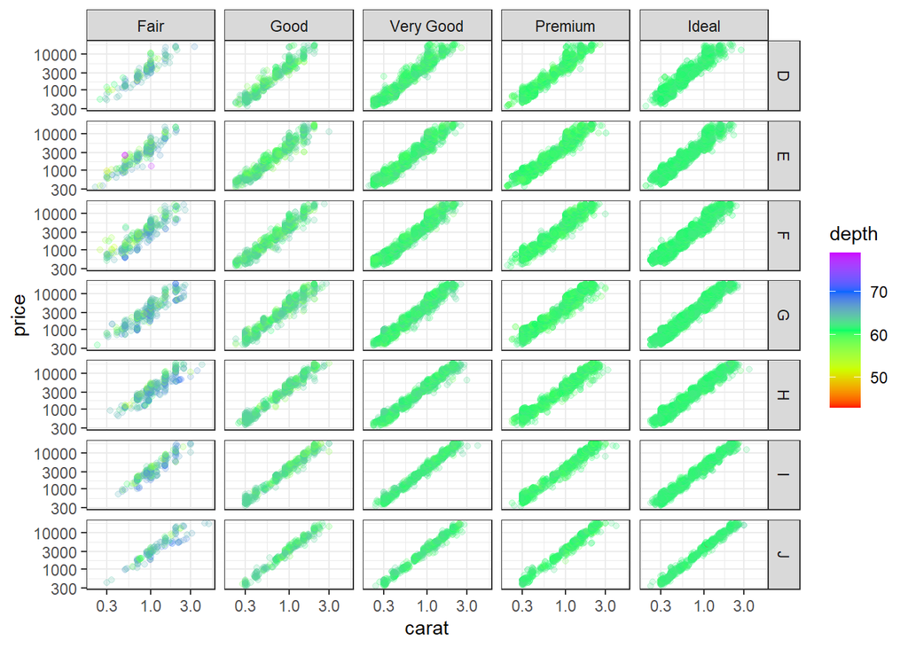

```r
ggplot(diamonds,
       aes(
         x = carat,
         y = price,
         color = depth)) +
  scale_color_gradientn(colors = rainbow(5)) +
  geom_point(alpha = 0.2) +
  facet_grid(color ~ cut) +
  scale_y_log10() +
  scale_x_log10() +
  theme_bw()
```

Multiple regression model (all interactions)

```r
m <- lm(log(price) ~ log(carat) * depth * cut * color, data = diamonds)
drop1(m, test = "F")
```

```
## Single term deletions
##
## Model:
## log(price) ~ log(carat) * depth * cut * color
##                            Df Sum of Sq    RSS     AIC F value    Pr(>F)
## <none>                                  2725.0 -160754
## log(carat):depth:cut:color 24    4.4115 2729.4 -160714  3.6291 4.421e-09 ***
## ---
## Signif. codes:  0 '***' 0.001 '**' 0.01 '*' 0.05 '.' 0.1 ' ' 1
```

Here is an alternative visualization that utilizes the hexbin package, but we’ll lose the ability to see any depth (which we couldn’t really see anyway).

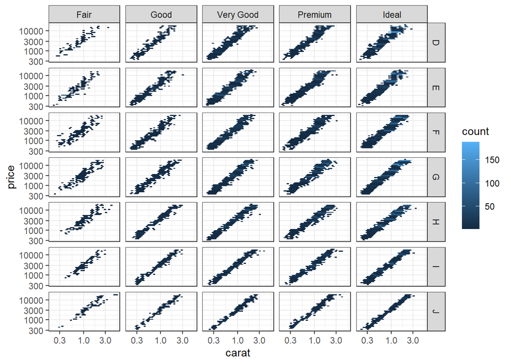

```r
ggplot(diamonds,
       aes(
         x = carat,
         y = price)) +
  geom_hex() +
  facet_grid(color ~ cut) +
  scale_y_log10() +
  scale_x_log10() +
  theme_bw()
```

## Additional resources

- [ggplot2 book](https://ggplot2-book.org/)
- [ggplot2 gallery](https://r-graph-gallery.com/)